# Analiza szeregów czasowych

Tomasz Przechlewski

Powiślańska Szkoła Wyższa (Kwidzyn/Poland)  
t.plata-przechlewski@psw.kwidzyn.edu.pl

21/2/2026

## Rodzaje danych

Przekrojowe = jednokrotny pomiar w tym samym momencie

Szeregi czasowe = wielokrotny pomiar powtarzany w pewnym stałym odstępie czasu (dane roczne, kwartalne, miesięczne, tygodniowe, dzienne itd)

W szeregu czasowym można zwykle wyróżnić długookresową tendencję (trend); powtarzalne wahania (sezonowość, np. liczba zgonów rośnie zimą, a spada latem); resztę traktuje się jako wartości przypadkowe. Reasumując:

$$TS = T + S + E$$

lub

$$TS = T \cdot S \cdot E$$

Pierwszy wariant nazywa się **addytywny** drugi **multiplikatywny**. W wariancie addytywnym zmiany (trendu/sezonowości) okres/okres są stałe; w wariancie multiplikatywnym **tempo zmiany** jest stałe, tj. zjawisko okres/okres rośnie/spada o x%. W jednostkach bezwzględnych oznacza to, że rośnie/spada coraz szybciej.

Celem statystycznej analizy szeregów czasowych jest opisanie oraz prognozowanie zmian wartości obserwowanych w czasie (na podstawie danych historycznych).

Generalnie jest to trudne zadanie, mówiąc oględnie :-) Ponieważ jest trudne, to metod i modeli jest *multum*. W tym dokumencie omówimy metody elementarne: wykres liniowy, średnie tempo zmian oraz trend liniowy

Pokażemy to na przykładach, ograniczając teorię do minimum.

## Wykres liniowy

W przypadku szeregów czasowych wykres liniowy (ewentualnie punktowy lub słupkowy) jest najpopularniejszy. Przykład: z bazy danych WHO (https://www.who.int/data/gho) pobrano informacje nt odsetka osób dorosłych z nadwagą (BMI 30 i więcej; *Prevalence of obesity among adults…*) dla Polski w latach 1975–2016.

Uwaga: WHO podaje wskaźniki surowe (*crude*) i standaryzowane; pobrano surowe

Wykres liniowy

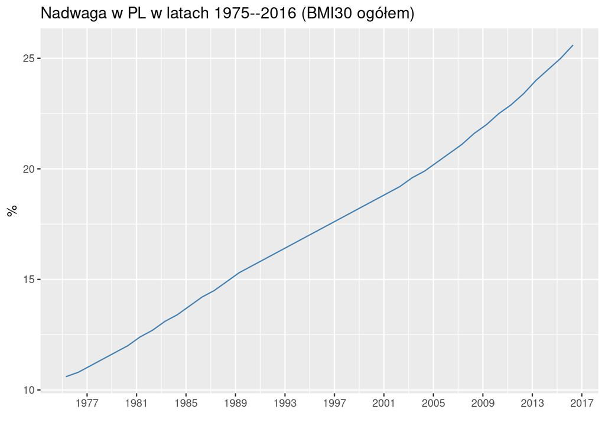

Interpretacja: czy zjawisko rośnie czy spada; jak szybko rośnie jak szybko spada.

Uwaga: można manipulować wykresem poprzez zmianę proporcji (współczynnika proporcji czyli po angielsku **aspect ratio**)

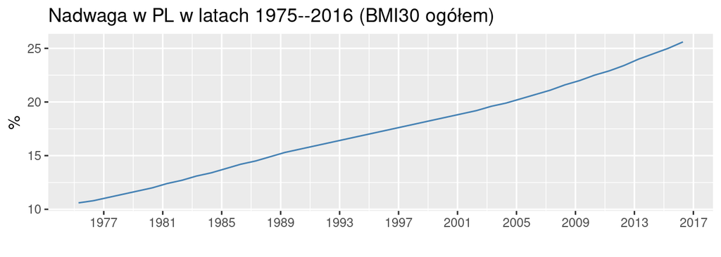

Oraz (albo raczej pośrednio) zakresem na osi OY;

Jeżeli oś OY nie zaczyna się od zera to krzywa będzie bardziej stroma bo efektywnie wykres będzie miał większe proporcje wysokość/szerokość:

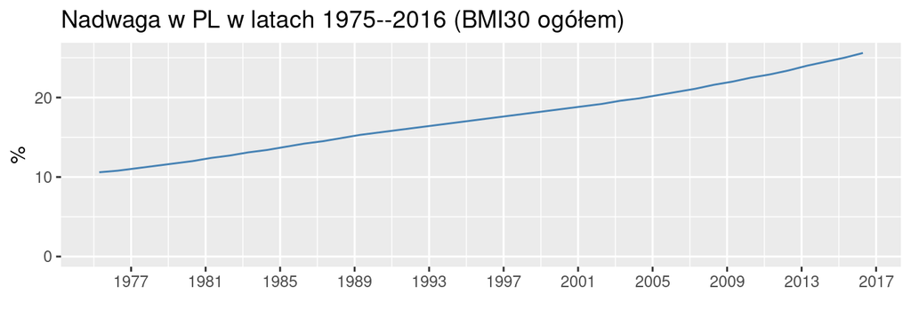

Puryści uważają że każdy wykres powinien zaczynać się od zera. Są przykłady zeznań przed komisją senacją w USA gdzie dowody prezentowane na wykresach **z niezerową linią bazową** były dyskwalifikowane jako manipulacja.

Słynna książka How to lie with statistics zawiera rozdział na temat zatytułowany **The Gee-Whiz Graphs**; https://en.wikipedia.org/wiki/Misleading_graph

Można umieścić wiele krzywych celem porównania:

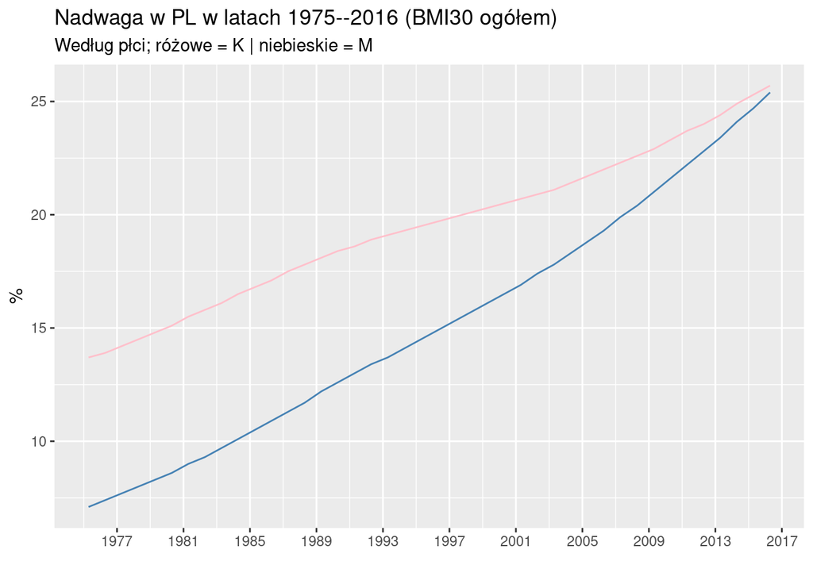

Jeżeli krzywe się **dobrze zachowują** (czytaj: nie przecinają się) na to sens; w innym przypadku trudno jest porównać krzywe. Nie należy też przesadzać z liczbą krzywych na wykresie. Na pewno coś co wygląda jak splątany makaron będzie bezużyteczne…

Punktowy:

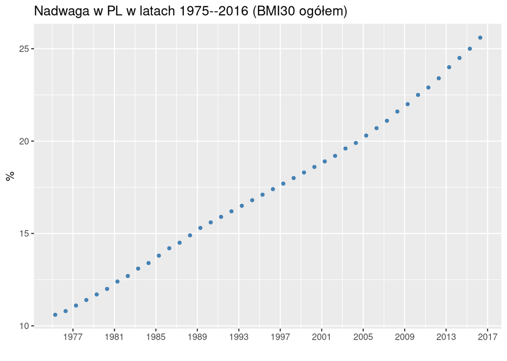

Nie uważam za dobry pomysł. Nie podkreśla ciągłości zjawisk w czasie

Słupkowy:

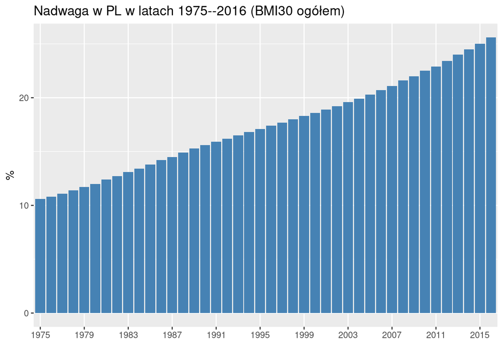

Jest OK. Ale wielosłupki zamiast wielu linii prowadzą do problemów:

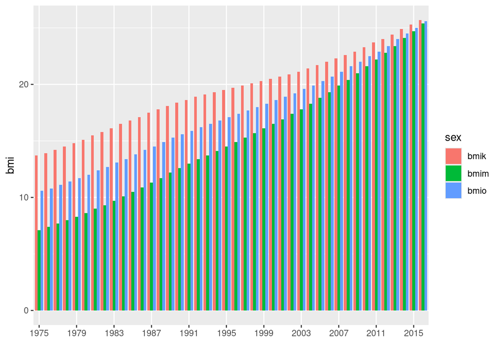

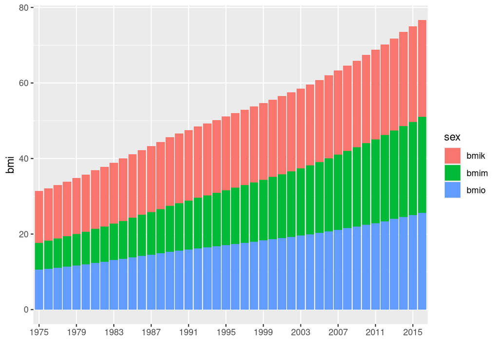

Oba dla mnie nieczytelne a do tego ten drugi wykres daje mylne wrażenie że łącznie otyłych jest 3/4 ludności (jak ktoś nieuważnie czyta)

## Roczna i miesięczna liczba zgonów

Liczba zgonów w Polsce (źródło: tabela `demo_magec` w bazie Eurostat) oraz miesięczna liczba zgonów w Polsce (źródło: tabela `demo_mmonth` w bazie Eurostat)

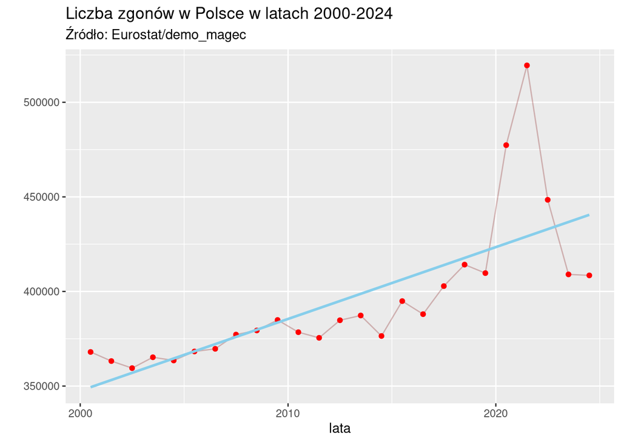

Dane miesięczne

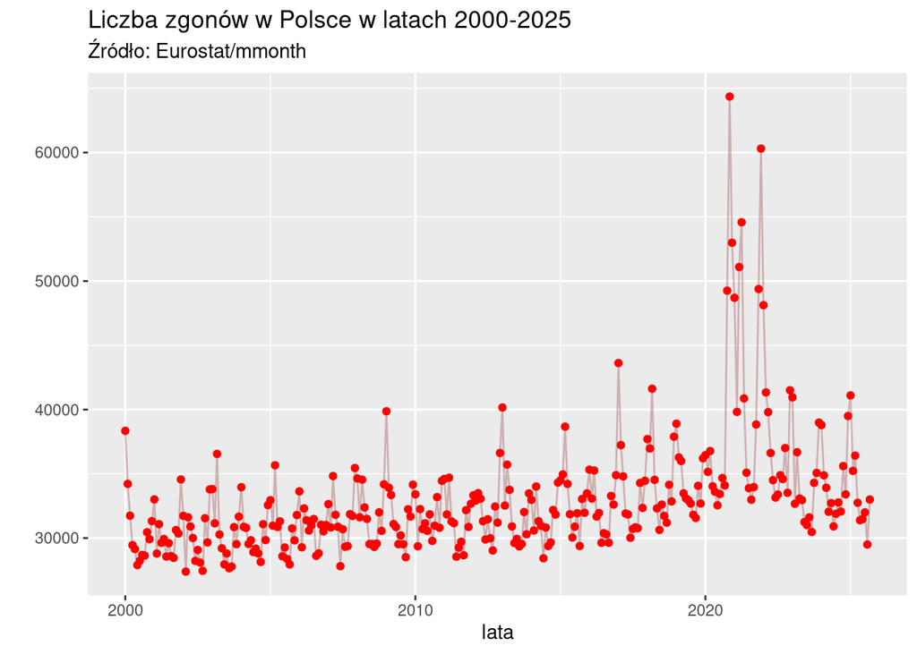

## Średnie tempo zmian

**Wskaźniki dynamiki** (indeksy) określają względną zmianę wartości szeregów czasowych (popularny procent zmiany), czyli $y_t/y_0$. Jeżeli podstawą porównań jest okres poprzedni $y_t/y_{t-1}$ to indeks nazywany jest **łańcuchowym**, jeżeli podstawa porównań jest stała, tj. $y_t/y_{c}$, to indeks nazywany jest **jednopodstawowy**.

Używamy średniej geometrycznej do obliczenia **średniego tempa zmian** zjawiska w czasie:

$$\bar y_g = \sqrt[n-1]{\frac{y_2}{y_1}
\frac{y_3}{y_2} \cdots
\frac{y_n}{y_{n-1}}} = \sqrt[n-1]{\frac{y_n}{y_1}}$$

Średnie tempo zmian liczby zgonów w Polsce w latach 2000–2024 wyniosło 0.435719, tj. przeciętnie w tym okresie zgony rosną o 0,4%. Wartość indeksu $y_{2024}/y_{2000}$ wynosi 110.9983778%.

## Trend liniowy

Trend liniowy jest opisany równaniem:

$$y = \beta_0 + \beta_1 t + \epsilon$$
gdzie: zmienna $t$ to numer kolejnego okresu (np. $t=1,\ldots,n$) $\epsilon$ oznacza składnik losowy.

Parametry $\beta_0$ oraz $\beta_1$ są szacowane metodą najmniejszych kwadratów. Ocena modelu: jak w przypadku modelu regresji liniowej: wielkość współczynnika determinacji + istotność parametru $\beta_1$. Dla danych dotyczących liczby zgonów otrzymano następujące wyniki:

```
##
## Call:
## lm(formula = zgony ~ t, data = z2)
##
## Residuals:
##    Min     1Q Median     3Q    Max
## -32023 -11450  -2498   2490  90381
##
## Coefficients:
##             Estimate Std. Error t value             Pr(>|t|)
## (Intercept) 345605.5    10713.3  32.260 < 0.0000000000000002 ***
## t             3796.9      720.7   5.269             0.000024 ***
## ---
## Signif. codes:  0 '***' 0.001 '**' 0.01 '*' 0.05 '.' 0.1 ' ' 1
##
## Residual standard error: 25980 on 23 degrees of freedom
## Multiple R-squared:  0.5469, Adjusted R-squared:  0.5272
## F-statistic: 27.76 on 1 and 23 DF,  p-value: 0.00002402
```

W latach 2000–2024 przeciętny roczny wzrost liczby zgonów wynosił około 3,8 tysiąca osób. Wielkość ta jest istotna statystycznie a wartość współczynnika determinacji wynosi 54%.

Przypatrując się wykresowi dostrzeżemy bez trudu, że obserwacje z lat 2020–22 mocno nie leżą na linii trendu i wiemy dlaczego. Takie zjawisko nazywa się uczenie **zaburzeniem strukturalnym**. Można poprawić model dodając do niego drugą sztuczną (*dummy*) zmienną, której wartości będą się równać 1 dla lat 2020–2022 oraz zero w pozostałych latach.

Taką zmienną nazywa się też często **zmienną zero-jedynkową**

$$y = \beta_0 + \beta_1 t + \beta_2 \textrm{covid} + \epsilon$$

gdzie: $\textrm{covid}=1$ w latach 2020–2022 oraz 0 w pozostałych

```
##
## Call:
## lm(formula = zgony ~ t + covid, data = z3)
##
## Residuals:
##    Min     1Q Median     3Q    Max
## -35545  -3981  -1063   2472  37744
##
## Coefficients:
##             Estimate Std. Error t value             Pr(>|t|)
## (Intercept) 356997.5     5390.6  66.225 < 0.0000000000000002 ***
## t             2219.5      396.2   5.602         0.0000124230 ***
## covid        75946.6     8791.5   8.639         0.0000000161 ***
## ---
## Signif. codes:  0 '***' 0.001 '**' 0.01 '*' 0.05 '.' 0.1 ' ' 1
##
## Residual standard error: 12680 on 22 degrees of freedom
## Multiple R-squared:  0.8968, Adjusted R-squared:  0.8875
## F-statistic: 95.62 on 2 and 22 DF,  p-value: 0.00000000001409
```

Po uwzględnieniu efektu COVID, liczba zgonów w okresie 2000–2024 rosła średnio o ok. 2,2 tys. rocznie. W latach 2020–2022 liczba zgonów była przeciętnie wyższa o ok. 75 tys. rocznie w porównaniu do poziomu wynikającego z trendu.

Oba współczynniki są istotne statystycznie, a wartość współczynnika determinacji wynosi prawie 90% (poprzednio 54%).

## Sezonowość

Prosty model trendu dla danych miesięcznych będzie — z oczywistych względów — słabo dopasowany do danych.

```
##
## Call:
## lm(formula = zgony ~ t, data = z2m)
##
## Residuals:
##     Min      1Q  Median      3Q     Max
## -7153.5 -2311.3  -781.5   939.6 29093.7
##
## Coefficients:
##              Estimate Std. Error t value            Pr(>|t|)
## (Intercept) 29168.300    473.043  61.661 <0.0000000000000002 ***
## t              24.303      2.645   9.188 <0.0000000000000002 ***
## ---
## Signif. codes:  0 '***' 0.001 '**' 0.01 '*' 0.05 '.' 0.1 ' ' 1
##
## Residual standard error: 4148 on 307 degrees of freedom
## Multiple R-squared:  0.2157, Adjusted R-squared:  0.2131
## F-statistic: 84.41 on 1 and 307 DF,  p-value: < 0.00000000000000022
```

Dodajmy zmienną `covid`:

```
##
## Call:
## lm(formula = zgony ~ t + covid, data = z3m)
##
## Residuals:
##     Min      1Q  Median      3Q     Max
## -7417.5 -2063.2  -561.7  1211.3 24323.0
##
## Coefficients:
##              Estimate Std. Error t value             Pr(>|t|)
## (Intercept) 29933.648    430.542  69.525 < 0.0000000000000002 ***
## t              14.506      2.602   5.576         0.0000000542 ***
## covid        6464.295    723.324   8.937 < 0.0000000000000002 ***
## ---
## Signif. codes:  0 '***' 0.001 '**' 0.01 '*' 0.05 '.' 0.1 ' ' 1
##
## Residual standard error: 3700 on 306 degrees of freedom
## Multiple R-squared:  0.378,  Adjusted R-squared:  0.3739
## F-statistic: 92.98 on 2 and 306 DF,  p-value: < 0.00000000000000022
```

Efekt sezonowości może zostać dodany do równania w postaci $k-1$ zmiennych sztucznych $M_i$, z których każda przyjmuje wartość 1 jeżeli obserwacja pochodzi z $i$-tego miesiąca, a zero w pozostałych miesiącach. W ten sposób model oszacuje wpływ danego miesiąca na wielkość zmiennej $y$.

```
##
## Call:
## lm(formula = zgony ~ t + covid + factor(month), data = z3m)
##
## Residuals:
##     Min      1Q  Median      3Q     Max
## -7598.0 -1202.1   -73.1   759.7 23827.9
##
## Coefficients:
##                   Estimate Std. Error t value             Pr(>|t|)
## (Intercept)      34026.371    635.647  53.530 < 0.0000000000000002 ***
## t                   15.137      2.036   7.434 0.000000000001147501 ***
## covid             6373.598    565.932  11.262 < 0.0000000000000002 ***
## factor(month)M02 -3836.137    802.721  -4.779 0.000002783737846158 ***
## factor(month)M03 -1550.390    802.729  -1.931               0.0544 .
## factor(month)M04 -4155.488    802.742  -5.177 0.000000418697423100 ***
## factor(month)M05 -5345.703    802.760  -6.659 0.000000000134455312 ***
## factor(month)M06 -7018.147    802.783  -8.742 < 0.0000000000000002 ***
## factor(month)M07 -6280.708    802.811  -7.823 0.000000000000092310 ***
## factor(month)M08 -6836.883    802.845  -8.516 0.000000000000000858 ***
## factor(month)M09 -7041.213    802.884  -8.770 < 0.0000000000000002 ***
## factor(month)M10 -3589.488    810.725  -4.428 0.000013439950307856 ***
## factor(month)M11 -3665.345    810.740  -4.521 0.000008923380100224 ***
## factor(month)M12  -662.323    810.760  -0.817               0.4146
## ---
## Signif. codes:  0 '***' 0.001 '**' 0.01 '*' 0.05 '.' 0.1 ' ' 1
##
## Residual standard error: 2894 on 295 degrees of freedom
## Multiple R-squared:  0.633,  Adjusted R-squared:  0.6168
## F-statistic: 39.14 on 13 and 295 DF,  p-value: < 0.00000000000000022
```

```
## # A tibble: 12 × 2
##    month      m
##    <chr>  <dbl>
##  1 M01   37048.
##  2 M02   33226.
##  3 M03   35527.
##  4 M04   32937.
##  5 M05   31762.
##  6 M06   30105.
##  7 M07   30858.
##  8 M08   30317.
##  9 M09   30127.
## 10 M10   33533.
## 11 M11   33472.
## 12 M12   36490.
```

Te sztuczne zmienne na wydruku noszą cokolwiek barokowe nazwy `factor(month)M02`–`factor(month)M012`. Zmiennych jest 11 ($k-1) a nie 12 i nie jest to błąd. Brakująca zmienna jest bazą porównań, np. w lutym umierało przeciętnie około 3836 mniej niż w **styczniu**. Podobnie interpretuje się inne wspóczynniki.

Można też interpretować współczynniki względem średniego poziomu zmiennej $y$ w roku. Wymaga to obliczenia wartości średniej wskaźników:

$$\bar M = M_2 + \cdots +
M_{12}$$

teraz dla każdego wskaźnika $M_1, \ldots, M_{12}$ należy wykonać $S_i=M_i - \bar M$ (przypominamy, że $M_1 = 0$).